# micro_processing

Robert J.D. Reid, Ph.D.

2023-03-20

# Process fluorophore data from Volocity output

## Filtering parameters

Some filtering may occur outside of the Volocity software. Examples may include object volume or mean intensity cutoffs. For now these are not implemented, but I put some example assignments here. Also included should be cutoffs for position in the microscope field such as acceptable X,Y, & Z ranges.

```r
RFP_low_vol_cutoff = 0.1
RFP_low_mean_cutoff = 360
```

In code below, we capture object volume, mean and total signal

Microscopy data comes from 4 files containing:

YFP objects from lacR-YFP binding lacO array RFP objects from tetR-RFP binding tetO array CFP objects denoting nuclear volume CFP spots from … binding parS array

Data is first run through a line-ending conversion script and ends up in the `data-conv` folder.

For now that is run as a separate Rmarkdown document that makes the conversions and a new directory for the converted files. That markdown should be converted to a straight R script which we can `source` from this main processing script.

From the converted data, load all files and concatenate

```r
dir = 'data-conv'

YFP_files = list.files(dir,pattern = "YFP.+?foci",full.names = TRUE,ignore.case = TRUE)

YFP = YFP_files %>% map_dfr(~read_csv(.)) %>%
  mutate (field = str_remove(`Item Name`," \\(registration corrected\\)")) %>%
  separate(field, into = c("sample","time","field"), sep = " ") %>% # times all T0
  replace_na(list(field="1")) %>%
  mutate(xfp_id = paste("yfp",str_remove(Name,"Object "))) %>%
  select(
    sample,
    #time,
    field,
    xfp_id,
    cenX = `Centroid X (µm)`,
    cenY = `Centroid Y (µm)`,
    cenZ = `Centroid Z (µm)`,
    signal_vol = `Volume (µm3)`,
    signal_intensity = `Sum (YFP)`,
    signal_mean = `Mean (YFP)`
  )
RFP_files = list.files(dir,pattern = "RFP.+?foci",full.names = TRUE,ignore.case = TRUE)

RFP = RFP_files %>% map_dfr(~read_csv(.)) %>%
  mutate (field = str_remove(`Item Name`," \\(registration corrected\\)")) %>%
  separate(field, into = c("sample","time","field"), sep = " ") %>%
  replace_na(list(field="1")) %>%
  mutate(xfp_id = paste("rfp",str_remove(Name,"Object "))) %>%
  select(
    sample,
    #time,
    field,
    xfp_id,
    cenX = `Centroid X (µm)`,
    cenY = `Centroid Y (µm)`,
    cenZ = `Centroid Z (µm)`,
    signal_vol = `Volume (µm3)`,
    signal_intensity = `Sum (RFP)`,
    signal_mean = `Mean (RFP)`
  )
CFP_nuc_files = list.files(dir, pattern = "CFP.+?nuclei", full.names = TRUE, ignore.case = TRUE)

CFP_nuclei = CFP_nuc_files %>% map_dfr(~read_csv(.)) %>%
  mutate (field = str_remove(`Item Name`," \\(registration corrected\\)")) %>%
  separate(field, into = c("sample","time","field"), sep = " ") %>%
  replace_na(list(field="1")) %>%
  mutate(xfp_id = paste("nucleus",str_remove(Name,"Object "))) %>%
  select(
    sample,
    #time,
    field,
    xfp_id,
    cenX = `Centroid X (µm)`,
    cenY = `Centroid Y (µm)`,
    cenZ = `Centroid Z (µm)`,
    signal_vol = `Volume (µm3)`,
    signal_intensity = `Sum (CFP)`,
    signal_mean = `Mean (CFP)`

  )
CFP_spot_files = list.files(dir, pattern = "CFP.+?foci", full.names = TRUE, ignore.case = TRUE)

CFP = CFP_spot_files %>% map_dfr(~read_csv(.)) %>%
  mutate (field = str_remove(`Item Name`," \\(registration corrected\\)")) %>%
  separate(field, into = c("sample","time","field"), sep = " ") %>%
  replace_na(list(field="1")) %>%
  #mutate(xfp_id = paste("cfp",str_remove(Name,"Point "))) %>%
  mutate(xfp_id = paste("cfp",str_remove(Name,"Point ")),
        signal_vol = NA, signal_mean=NA) %>%
  select(
    sample,
    #time,
    field,
    xfp_id,
    cenX = `Position X (µm)`,
    cenY = `Position Y (µm)`,
    cenZ = `Position Z (µm)`,
    signal_vol,
    signal_intensity = `Intensity (CFP)`,
    signal_mean
  )
```

The separate data files are next concatenated. Right now there are no filters implemented, but this is where they would be run if necessary.

```r
# this is where ad-hoc cutoffs would be implemented
# RFP = RFP %>%    # not very "functional", but the Gods of lambda calculus are all dead now
#   filter(signal_mean > RFP_low_mean_cutoff)

full_data = bind_rows(YFP,RFP,CFP,CFP_nuclei)

#*** candidate for saving or combining into a large data object
```

Split data by sample(colony) and field(micro image), cluster by position and save as data object

```r
data_list = full_data %>%
  select(-signal_vol,-signal_intensity,-signal_mean) %>%
  split(~.$sample + .$field,drop = TRUE) %>%
  map(select,-sample:-field) %>%
  map(remove_rownames) %>%
  map(column_to_rownames,var="xfp_id")

dist_list = map(data_list,dist)
clust_list = map(dist_list,hclust,"complete")

color_set = c(rfp = "red", cfp = "blue",
               yfp = "yellow", nuc = "grey")

dend_list = map(clust_list,as.dendrogram)
dend_list = map(dend_list,set,"leaves_pch",19) # filled circles
dend_list = map(dend_list,~set(.x,
                                 "leaves_col", color_set[str_sub(labels(.x),1,3)]))
saveRDS(dend_list,"dend.RDS")
```

Clustering performed above will divide the signals into individual groups that define yeast cells.

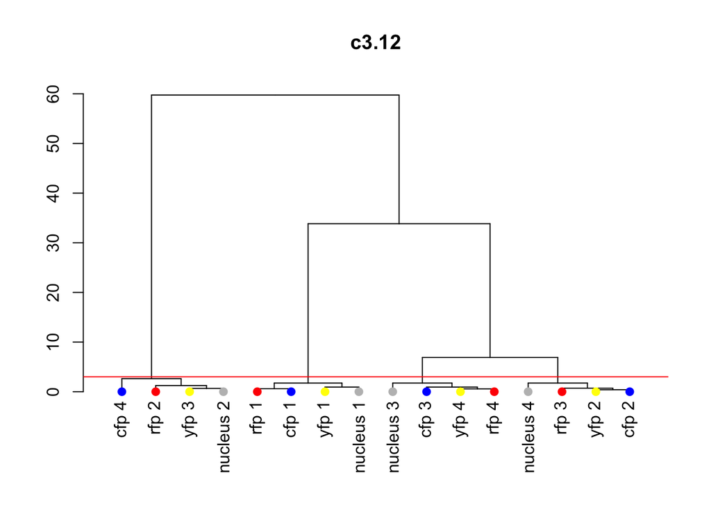

```r
example = 4
plot(dend_list[[example]], main=names(dend_list[example]))
abline(h=3,col="red")
```

Now we can “cut” the clusters at distance = 3 and build list of signals and parameters by cluster

```r
cluster_member_list <- map(clust_list,stats::cutree,h=3) # cutree masked by dendextend

nuclear_cluster_list <- map(cluster_member_list,function(x){
  y <- x[which(str_detect(names(x),"nucleus"))] # subsets cluster numbers named "nucleus..."
  return(x[x %in% y]) # subsets only cluster numbers that have nucleus
})
```

The `cutree` function returns named vectors of cluster numbers. The serialized signal designation becomes the vector names. Signals in the same field with the same cluster # will be within ~ 3µM of each other.

Convert these vectors into a dataframe that is then re-split by sample/field/cluster to get a list object for each cell. We can then pack these lists with all meta-info for each signal

```r
cluster_df <- imap(nuclear_cluster_list,~ tibble(sample.field=.y,xfp_id=names(.x),cluster_number=.x)) %>%
  bind_rows() %>%
  separate(col=sample.field, into = c("sample","field"),sep = "\\.") %>%
  select(sample,field,cluster_number,xfp_id) %>%
  arrange(sample,field,cluster_number,xfp_id)


# unclear if this is needed
# sf_cluster_list <- cluster_df %>%
#   left_join(full_data) %>%
#   split(~.$sample + .$field + .$cluster_number,drop = TRUE) %>%
#   map(select,c(-1:-3)) %>%
#   map(function (x){
#   split(x,x$xfp_id) %>%
#     map(function(x){
#       as.numeric(unlist(x)[-1])
#       })
#   })

# which fluors in each cluster
cluster_sig_list <- cluster_df %>%
  arrange(xfp_id) %>%
  split(~.$sample + .$field + .$cluster_number,drop = TRUE) %>%
  map(as.list) %>%
  map(tidyselect:::select,starts_with("xfp_id")) %>%
  map(function(x){
    # need to return the whole list
    x$signal = paste(str_sub(x$xfp_id,1,3),collapse = " ")
    return(x)
  })

# use list of fluors to pull out distance matrices

# could not figure out how to do this with a `map` or `apply` function so
# lines below predefine the loop output container so we don't get the
# cost of an accumulating dataset

cluster_set_dist <- vector("list", length(cluster_sig_list)) # this would not be necessary using map

names(cluster_set_dist) <- names(cluster_sig_list) # this would not be necessary using map

for(i in seq_along(cluster_sig_list)) {
  y <- names(cluster_sig_list[i])
  x <- cluster_sig_list[[i]]$xfp_id
  if (identical(x, character(0))) next # likely bc single fluor
  xfp <- x[which(str_detect(x,"fp \\d"))] # ignore CFP nuclei for distance matrices
  y_sub <- str_replace(y,"(.*)\\.\\w+","\\1") # drops after last "."
  k <- as.matrix(dist_list[[y_sub]]) # extracts colony.field distance list
  l <- k[rownames(k) %in% xfp, # subsets that distance matrix
         colnames(k) %in% xfp]
  l[!lower.tri(l)] <- NA # blanks upper tri
  cluster_set_dist[[i]] <- l
}
```

### Cluster meta data for app

We want data about specific clusters to present along side individual denrograms

```r
##################

### Make strings of fluorophore observations in df

#*** candidate for saving or combining into a large data object

cluster_signals_df <- cluster_df %>%
  arrange(xfp_id) %>%
  #filter(!str_detect(xfp_id,"nucleus")) %>%
  group_by(sample,field,cluster_number) %>%
  summarise(
    signals = reduce(xfp_id,paste,collapse = " "),
    signal_code = reduce(str_sub(xfp_id,1,3), paste, collapse = " ")
  ) %>%
  ungroup()
### 'position' of cluster is mean of all objects in x,y,z


cluster_pos <- cluster_df %>%
  left_join(full_data) %>%
  group_by(sample,field,cluster_number) %>%
  summarise(
    loc.x = mean(cenX),
    loc.y = mean(cenY),
    loc.z = mean(cenZ)
  ) %>%
  ungroup()
### ID sample,field,cluster with inbound nuclei
# This needs to go way above here
# At least the numeric cutoffs should be defined above in variables
# and be called here

inbound_nuclei <- cluster_df %>%
  filter(str_detect(xfp_id,"nucleus")) %>%
  left_join(full_data) %>%
  filter(cenZ >= 1.5 & cenZ <= 3.3) %>%
  filter(cenX >= 1.5 & cenX <= 85) %>%
  filter(cenY >= 1.5 & cenY <= 64) %>%
  select(sample,field,cluster_number) %>%
  unite("cluster_id",c(sample,field,cluster_number),remove = FALSE)
```

```r
#cluster_signals_df <- cluster_signals_df %>%



##################

### Get individual distances between each pair of fluors

### RY

RYdf <- map(cluster_set_dist,function(m) {

  y <- grep("yf",rownames(m),value = TRUE)
  r <- grep("rf",rownames(m),value = TRUE)
  c <- grep("cf",colnames(m),value = TRUE)

  # This is only considering colonies that have
  # exactly 3 signals
  # this needs to be rewritten so it is more general
  # this also is only looking for a minimum
  # it is not implementing a static cutoff value

  if (length(y)+length(r)+length(c) > 3 |
      length(y)+length(r)+length(c) < 2) {
    rval <- c(NA,NA,NA)
    names(rval) <- c("ry","cy","cr")
    return(rval)
  } else {
    if(is_empty(r) | is_empty(y)) ry=NA
    else ry = min(m[r,y])
    if(is_empty(c) | is_empty(y)) cy=NA
    else cy = min(m[c,y])
    if(is_empty(c) | is_empty(r)) cr=NA
    else cr = min(m[c,r])
    rval <- c(ry,cy,cr)
    names(rval) <- c("ry","cy","cr")
    return(rval)
  }
}) %>%
  as_tibble() %>%
  t() %>%
  as.data.frame() %>%
  rownames_to_column("sample.field.group") %>%
  rename(c("ry"=V1,"cy"=V2,"cr"=V3)) %>%
  separate(col=sample.field.group,into = c("sample","field","cluster_number"),sep = "\\.") %>%
  mutate(cluster_number = as.integer(cluster_number))


# apply filters here
final_df <- inbound_nuclei %>%
  left_join(cluster_signals_df) %>%
  left_join(cluster_pos) %>%
  left_join(RYdf)
saveRDS(final_df,"cluster-meta.RDS")
```

## Analysis section

First we will make a couple of tables. The first is the distribution of signal types by colony. The second is the colocalized signals in groups that have all four channels.

```r
table_one <- final_df %>%
  filter(str_detect(signals,"nucleus")) %>% # remove CPF spot only signals
  group_by(sample) %>%
  count(signal_code) %>%
  arrange(as.numeric(str_remove(sample,"c")),desc(n)) %>%
  ungroup()

table_two <- final_df %>%
  filter(signal_code == "cfp nuc rfp yfp") %>%
  mutate(coloc = case_when(
    (ry < cy) & (ry < cr) ~ "ry",
    (cy < ry) & (cy < cr) ~ "cy",
    (cr < cy) & (cr < ry) ~ "cr",
  )) %>%
  group_by(sample) %>%
  count(coloc) %>%
  arrange(as.numeric(str_remove(sample,"c")),desc(n))


signal_codes <- table_one %>%
  complete(sample,signal_code,fill = list(n=0)) %>%
  group_by(sample) %>%
  mutate(
    prop = n/sum(n)
  ) %>%
  ungroup() %>%
  select(-n) %>%
  pivot_wider(names_from = signal_code,values_from = prop) %>%
  column_to_rownames(var = "sample")


library(kableExtra)
kbl(table_one,
    col.names = c("Sample","Signals","n"),
    align = c('c','c','c'))
```

| Sample | Signals | n |
| --- | --- | --- |
| c3 | cfp nuc rfp yfp | 194 |
| c3 | cfp nuc rfp | 18 |
| c3 | cfp nuc | 13 |
| c3 | cfp nuc yfp | 9 |
| c3 | cfp nuc rfp rfp yfp | 3 |
| c3 | nuc rfp yfp | 2 |
| c3 | cfp cfp nuc yfp | 1 |
| c3 | cfp nuc rfp yfp yfp | 1 |

```r
kbl(table_two,
    col.names = c("Sample "," co-localized ","n"),
    align = c('c','c','c'))
```

| Sample | co-localized | n |
| --- | --- | --- |
| c3 | ry | 173 |
| c3 | cr | 12 |
| c3 | cy | 9 |

Now we can present the signals graphically for the whole set

```r
signal_classes <- full_data %>%
  left_join(cluster_df) %>%
  left_join (cluster_signals_df) %>%
  mutate(
    cluster_number = unname(cluster_number)
  ) %>%
  drop_na(cluster_number) %>%
  unite("cluster_id",c(sample,field,cluster_number),remove = FALSE) %>%
  filter(cluster_id %in% inbound_nuclei$cluster_id)
```

Now plot by class

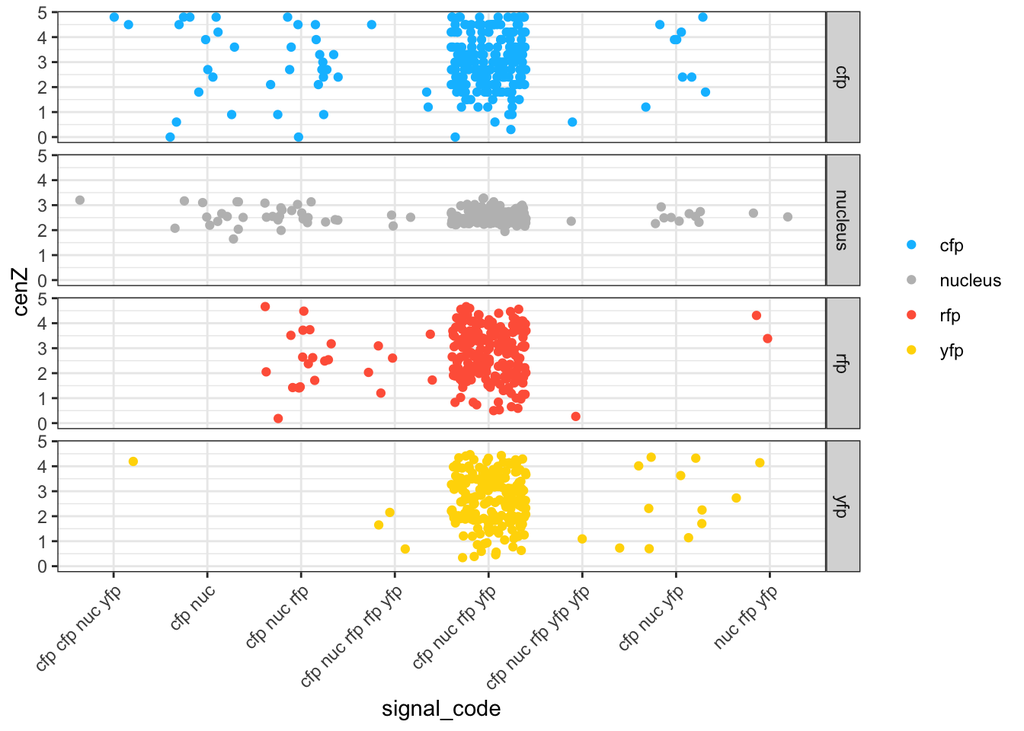

```r
signal_classes %>%
  #filter(field == 17) %>%
  ggplot(aes(x=signal_code,y=cenZ,color=str_extract(xfp_id,"[:alpha:]+"))) +
  geom_point(position = "jitter") +
  #geom_text(aes(label=cluster_number),position = "jitter") +
  theme(axis.text.x = element_text(angle = 45,hjust = 1)) +
  scale_color_manual(values=c("deepskyblue","grey","tomato","gold")) +
  facet_grid(str_extract(xfp_id,"[:alpha:]+") ~ .) +
  theme(legend.title = element_blank())
```